# Ofimatica con Power Point

Breves consejos para trabajar con PowerPoint

Luis Jose Zapata Bobadilla

2021-07-06

PowerPoint es el software de diapositivas más utilizado en el ámbito empresarial. Para un uso eficiente y rápido de este software, hay que considerar algunos temas.

## Acceso rápido y atajos

Primero, tener a la mano el acceso rápido a funciones de uso regular es muy importante. La **barra de acceso rápido** se encuentra en la parte superior izquierda de la aplicación, y es posible añadir más opciones de las definidas de forma predeterminada, como por ejemplo **Enviar por correo electrónico** o el **Autocorrector.**

[figure not shown]

Incluso, al presionar en **Más comandos…** se abre una lista con todos los comandos disponibles. Uno de bastante utilidad puede ser **Pegado especial**, si es que se suele pegar imágenes desde otras aplicaciones como Excel o Word.

Es posible acceder a estas comandos con atajos de teclado: “**Alt + Número**”, donde el número es el orden en el que se muestra.

## Reemplazar Fuentes

Cuando se compilan diapositivas de diferentes fuentes, es posible que el tipo de letra cambie según la presentación. Para unificar el formato, es posible reemplazar todas las fuentes de texto por una sola. Para eso, hacer clic en **Reemplazar Fuente** en la barra de reemplazar.

[figure not shown]

De esta manera podemos unificar todas las fuentes de texto en las diapositivas por una sola.

## Clasificador de diapositivas

Si se trabajan con muchas diapositivas en una sola presentación, es conveniente agruparlas. De esta forma, se pueden clasificar varias diapositivas y comprimirlas si no se desea verlas.

Para agregar una sección, hacer clic derecho sobre la diapositiva o diapositivas de interés, y elegir **Agregar sección**.

También se puede acceder a la **Vista de clasificador** que nos permite ver las diapositivas según su clasificación.

## Temas, Plantillas y Patrones

Power Point ofrece varios temas de diseño por defecto. Un **tema** es un conjunto de colores, fuentes y fondos que se aplican a las diapositivas para lograr un aspecto unificado y profesional.

Una **plantilla** es un tema, al que adicionalmente, se le agrega el patrón de presentación. El **patrón de presentación** es un esquema de diapositivas que definen el orden y **diseño de diapositivas** disponibles en un determinado tema. La plantilla adicionalmente se puede guardar y abrir en otras presentaciones. El patrón de presentación es el estilo y tipo de diapositivas que una presentación seguirá para mantener un formato unificado.

Para poder visualizar el patrón de presentación, se debe hacer clic en la pestaña **Vista**. Dentro de **Vistas Patrón** en **Patrón de diapositivas**.

[figure not shown]

El patrón de diapositivas (1) es la diapositiva superior en el panel de miniaturas situado a la izquierda de la ventana. Los diseños de diapositiva (2) relacionados aparecen justo debajo del patrón de diapositivas

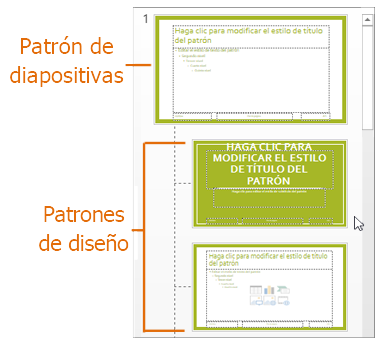

Los **patrones de diseño** son aquellos tipos de diapositiva que están disponibles al crear una dispositiva (“Normal”, “Título y contenido”,“Blanco”,“Solo título”, etc.). El **patrón de diapositivas** abarca a todas ellas y define su fondo, tipo y tamaño de letra, colores, etc.

[figure not shown]

Los **temas**, adicionalmente a los patrones, contienen un esquema de colores que son armoniosos entre sí. Los temas pueden visualizarse en la pestaña **Diseño**.

Tanto los temas como los patrones pueden modificarse y guardarse para su uso futuro y en otras diapositivas a traves de las plantillas.

## Modificar Patrones y Estilos

Para poder modificar patrones y estilos nos ubicaremos en la pestaña **Vista** y en **Vista Patrón - Patrón de diapositivas.**

Desde allí, en **Fondo** podemos seleccionar **Colores** y **Fuentes** desde donde podremos elegir el formato predeterminado (tipo de letra y color) en la presentación, para títulos y contenido.

Adicionalmente, desde allí podremos modificar la ubicación de los “marcadores” (imágenes, texto, etc) así como añadir/borrarlos. De esta manera podríamos crear patrones de diseño para diapositivas de introducción, de contenido y de anexos.

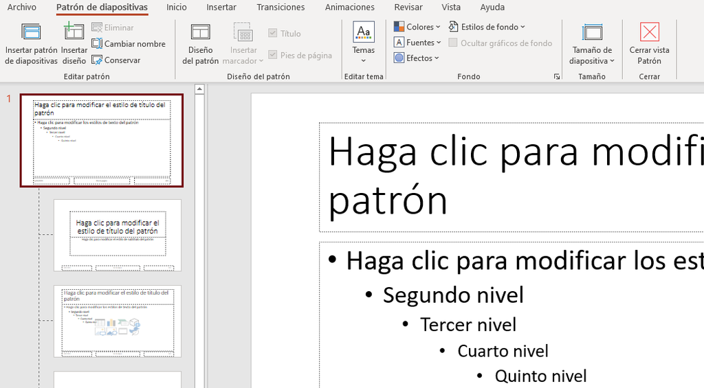

De esta manera podríamos tener formatos empresariales de diapositivas predefinidos para distintos fines.

Finalmente, es posible guardar el tema o plantilla, al seleccionar **Guardar** y seleccionando el tipo **Plantilla de PowerPoint** (habilitada para macros en caso fuese necesario).

## Insertar Diapositivas de Otra Presentación

Adicionalmente, es posible insertar una diapositiva de otra presentación de modo que esta tenga el formato del patrón creado. Para eso, en la **Vista Normal** se debe hacer clic en **Nueva Diapositiva** y posteriormente en **Volver a utilizar diapositiva…**

[figure not shown]

Así se abrirá una pestaña en el lado derecho de la pantalla, en el que buscaremos la presentación de nuestro interés y seleccionaremos las diapositivas buscadas. **No se copiará el formato** a menos de que esté marcada la casilla *Mantener formato de origen*. Esto es así para que el formato se adapte automáticamente al estilo del patrón, ahorrándonos tiempo y esfuerzo.

## Vistas, reglas y alinear objetos

Dentro de la pestaña **Vista** es posible ver varios tipos de vistas. La **Vista Normal** es la vista que usualmente vemos al abrir la diapositiva. La **Vista Patrón** fue revisada anteriormente. Dentro de las vistas y en **Mostrar**, podemos hacer clic en **Regla, líneas de cuadrícula y Guías.**

La **Regla** será vertical y horizontal. Las Lineas de cuiadrícula pueden ser configuradas para aumentar o disminuir el espacio entre ambas. Con las lineas de cuadrícula también es posible alinear los objetos.

Es posible alinear objetos con la opción **Alinear**. Es una forma rápida y facil de alinear objetos (textos, imágenes, etc.) ya sea de forma horizontal y vertical. También nos permite alinear varios objetos a la vez.

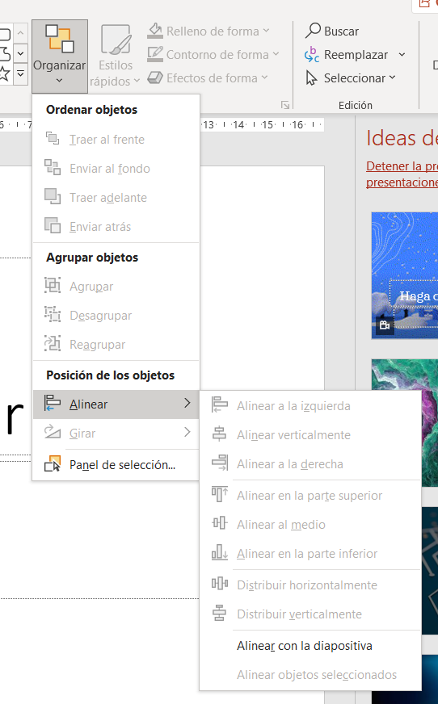

### Fuentes:

- [Microsoft PowerPoint Avanzado 2013.pdf (saludarequipa.gob.pe)](https://www.saludarequipa.gob.pe/camana/curso1/modulos/Microsoft%20PowerPoint%20Avanzado%202013.pdf)
- [¿Qué es un patrón de diapositivas? - Soporte de Office (microsoft.com)](https://support.microsoft.com/es-es/office/%C2%BFqu%C3%A9-es-un-patr%C3%B3n-de-diapositivas-b9abb2a0-7aef-4257-a14e-4329c904da54)
- [Crear y guardar una plantilla de PowerPoint - PowerPoint (microsoft.com)](https://support.microsoft.com/es-es/office/crear-y-guardar-una-plantilla-de-powerpoint-ee4429ad-2a74-4100-82f7-50f8169c8aca)
- [¿Qué es un diseño de diapositiva? - Soporte de Office (microsoft.com)](https://support.microsoft.com/es-es/office/%C2%BFqu%C3%A9-es-un-dise%C3%B1o-de-diapositiva-99da5716-92ee-4b6a-a0b5-beea45150f3a)
- [Guías para organizar los elementos en una diapositiva de PowerPoint - PowerPoint (microsoft.com)](https://support.microsoft.com/es-es/office/gu%C3%ADas-para-organizar-los-elementos-en-una-diapositiva-de-powerpoint-33854dfa-e0d1-43ff-8971-667b19512de3)